# Homework 1 Solutions

Alexandra Chronopoulou

8/31/2021

## Part I: Practice Questions

#### 1. Prove the following statements:

1. The sum of the $y$ observations is the same as the sum of the fitted values.
   $$\begin{align*}
   \sum_i \hat{y_i} &= \sum_i \left(\hat{\beta}_0+ \hat{\beta}_1 x_i \right)\\
   &= n \hat{\beta_0} + \hat{\beta}_1 n \bar{x}\\
   &= n \left(\bar{y} - \hat{\beta_1} \bar{x} \right) + \hat{\beta}_1 n \bar{x} = n \bar{y} = \sum_i y_i
   \end{align*}$$
2. The sum of the residuals weighted by the fitted values is zero.

   $$\begin{align*}
   \sum_i \hat{y_i} r_i &= \sum_i \left(\hat{\beta}_0+ \hat{\beta}_1 x_i \right) r_i\\
   &= \hat{\beta_0} \sum r_i + \hat{\beta}_1 \sum_i x_i r_i = 0,
   \end{align*}$$
   since $\sum r_i = 0$ and $\sum_i x_i r_i = 0$.

#### Muscle Mass

1. Obtain the estimated regression line. Plot the estimated regression function and the data. Does a linear regression function appear to give a good fit here? Does your plot support the anticipation that muscle mass decreases with age? Explain.

   ```r
   library(ggplot2)
   muscle = read.table("muscle.txt", header=TRUE)
   head(muscle)
   ```

   |  | mass | age |
   | --- | --- | --- |
   | 1 | 106 | 43 |
   | 2 | 106 | 41 |
   | 3 | 97 | 47 |
   | 4 | 113 | 46 |
   | 5 | 96 | 45 |
   | 6 | 119 | 41 |

   ```r
   attach(muscle)


   muscle.reg = lm(mass~age)
   summary(muscle.reg)
   ```

   ```
   ##
   ## Call:
   ## lm(formula = mass ~ age)
   ##
   ## Residuals:
   ##      Min       1Q   Median       3Q      Max
   ## -16.1368  -6.1968  -0.5969   6.7607  23.4731
   ##
   ## Coefficients:
   ##             Estimate Std. Error t value Pr(>|t|)
   ## (Intercept) 156.3466     5.5123   28.36   <2e-16 ***
   ## age          -1.1900     0.0902  -13.19   <2e-16 ***
   ## ---
   ## Signif. codes:  0 '***' 0.001 '**' 0.01 '*' 0.05 '.' 0.1 ' ' 1
   ##
   ## Residual standard error: 8.173 on 58 degrees of freedom
   ## Multiple R-squared:  0.7501, Adjusted R-squared:  0.7458
   ## F-statistic: 174.1 on 1 and 58 DF,  p-value: < 2.2e-16
   ```

      ```r
      muscle.reg$coefficients[2]
      ```

      ```
      ##       age
      ## -1.189996
      ```

   2. a point estimate of the mean muscle mass for women aged $X=60$ years.

   ```r
   predict(muscle.reg, newdata=data.frame(age = 60))
   ```

   ```
   ##        1
   ## 84.94683
   ```

   3. the value of the residual for the eighth case.

   ```r
   muscle.reg$residuals[8]
   ```

   ```
   ##        8
   ## 4.443252
   ```

   4. a point estimate for $\sigma^2$.

   ```r
   muscle.anova = anova(muscle.reg)
   muscle.anova
   ```

   |  | Df | Sum Sq | Mean Sq | F value | Pr(>F) |
   | --- | --- | --- | --- | --- | --- |
   | age | 1 | 11627.486 | 11627.48584 | 174.062 | 4.123987e-19 |
   | Residuals | 58 | 3874.447 | 66.80082 | NA | NA |

   ```r
   muscle.anova[2,3] # we want to extract the MSE
   ```

   ```
   ## [1] 66.80082
   ```

#### 2. Copier Maintenance

The Tri-City office Equipment Corporation sells an imported copier on a franchise basis and performs preventive maintenance and repair service on this copier. The data have been collected from 45 recent calls on users to perform routine preventive maintenance service. For each call, $x$ is the number of copiers serviced and $y$ is the total number of minutes spent by the service person. Assume that a simple linear regression model is appropriate. The data can be found on Moodle in the data set .

1. Obtain the estimated regression function.

   ```r
   library(ggplot2)
   copier = read.table("copier.txt", header=TRUE)
   head(copier)
   ```

   |  | y | x |
   | --- | --- | --- |
   | 1 | 20 | 2 |
   | 2 | 60 | 4 |
   | 3 | 46 | 3 |
   | 4 | 41 | 2 |
   | 5 | 12 | 1 |
   | 6 | 137 | 10 |

   ```r
   attach(copier)

   ## Linear Regression
   copier.reg = lm(y~x)
   summary(copier.reg)
   ```

   ```
   ##
   ## Call:
   ## lm(formula = y ~ x)
   ##
   ## Residuals:
   ##      Min       1Q   Median       3Q      Max
   ## -22.7723  -3.7371   0.3334   6.3334  15.4039
   ##
   ## Coefficients:
   ##             Estimate Std. Error t value Pr(>|t|)
   ## (Intercept)  -0.5802     2.8039  -0.207    0.837
   ## x            15.0352     0.4831  31.123   <2e-16 ***
   ## ---
   ## Signif. codes:  0 '***' 0.001 '**' 0.01 '*' 0.05 '.' 0.1 ' ' 1
   ##
   ## Residual standard error: 8.914 on 43 degrees of freedom
   ## Multiple R-squared:  0.9575, Adjusted R-squared:  0.9565
   ## F-statistic: 968.7 on 1 and 43 DF,  p-value: < 2.2e-16
   ```

   ```r
   copier.reg$coefficients
   ```

   ```
   ## (Intercept)           x
   ##  -0.5801567  15.0352480
   ```

   The estimated regression line is:
   $$y = -0.5802 + 15.0352 \, x$$
2. Plot the estimated regression function and the data. How well does the estimated regression function fit the data?

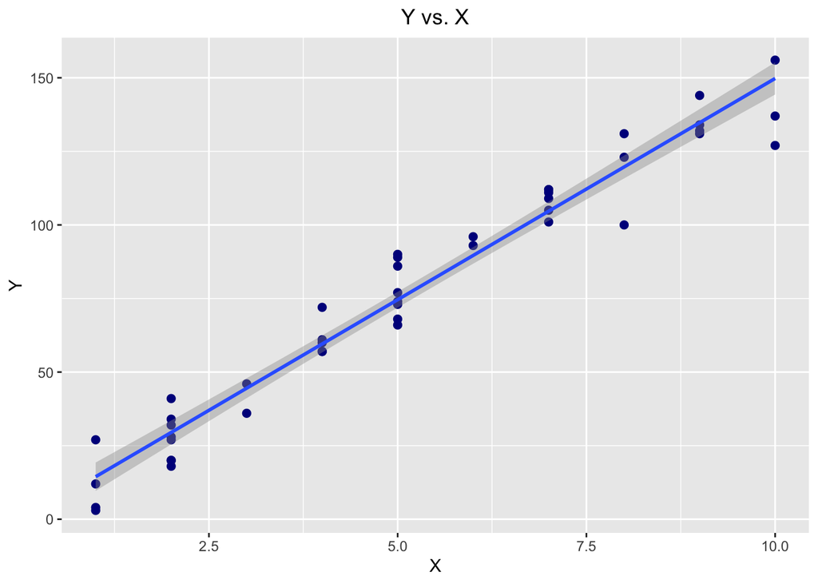

   ```r
   ## Plot: Points & Regression Line.
   scatterplot = ggplot(copier,  aes(x, y)) +
     geom_point(size=2, color='darkblue') +
     labs(title="Y vs. X",y="Y",x="X") +
     theme(legend.position = "none") +
     theme(plot.title = element_text(hjust = 0.5)) +
     geom_smooth(method=lm)

   plot(scatterplot)
   ```

   The estimated regression function has a very good fit.
3. Interpret $\hat{\beta}_0$ in your estimated regression function. Does $\hat{\beta}_0$ provide any relevant information here? Explain.

   $\hat{\beta}_0 = -0.5801567$
4. Obtain a point estimate of the mean service time when $x=5$ copiers are serviced.

   ```r
   predict(copier.reg, newdata=data.frame(x = 5))
   ```

   ```
   ##        1
   ## 74.59608
   ```

5. Estimate the change in the mean service time when the number of copiers serviced increases by one. Use and 90% confidence interval. Interpret your confidence interval.

   ```r
   copier.reg$coefficients[2]
   ```

   ```
   ##        x
   ## 15.03525
   ```

   ```r
   confint(copier.reg, 'x', level=0.9)
   ```

   ```
   ##        5 %     95 %
   ## x 14.22314 15.84735
   ```

   We can also compute itas follows:

   ```r
   copier.coef=summary(copier.reg)$coef
   c("lower" = copier.coef[2,1] - qt(0.95, df = copier.reg$df) * copier.coef[2, 2],
     "upper" = copier.coef[2,1] + qt(0.95, df = copier.reg$df) * copier.coef[2, 2])
   ```

   ```
   ##    lower    upper
   ## 14.22314 15.84735
   ```

6. Conduct a test to determine whether or not there is a linear association between $x$ and $y$ here. Control the $\alpha$ risk at 0.01. State the alternatives, decision rule and conclusion. What is the $p$-value of your test?

   Essentially, we want to perform a hypothesis test for the slope. Specifically, the alternatives are
   $$\begin{cases}
   &H_0: \beta_1=0\\
   &H_{\alpha}: \beta_1 \neq 0
   \end{cases}$$
   The test statistic is given by:

   ```r
   summary(copier.reg)$coef[2,3]
   ```

   ```
   ## [1] 31.12326
   ```

   while the corresponding critical value of the T distribution is

   ```r
   qt(1-(0.01/2), df = copier.reg$df)
   ```

   ```
   ## [1] 2.695102
   ```

   We want to test whether $\beta_1>14$, so the alternatives are
   $$\begin{cases}
   &H_0: \beta_1 = 14\\
   &H_{\alpha}: \beta_1 \geq 14
   \end{cases}$$
   The test statistic is given by:
   $$t = \frac{\hat{\beta}_1 - 14}{sd_{\hat{\beta}_1}}$$

   ```r
   (summary(copier.reg)$coef[2,1]-14)/(summary(copier.reg)$coef[2,2])
   ```

   ```
   ## [1] 2.142984
   ```

   while the corresponding critical value of the T distribution is

   ```r
   qt(0.95, df = copier.reg$df)
   ```

   ```
   ## [1] 1.681071
   ```

   So, the decision rule is: since 2.142984 $>$ 1.681071, we reject the null and conclude that this standard is not being Satisfied by Tri-City.
8. Obtain a 90% confidence interval for the mean service time on calls in which 6 copiers are serviced. Interpret your confidence interval.

   ```r
   predict(copier.reg, newdata=data.frame(x = 6), interval="confidence", level=0.9)
   ```

   ```
   ##        fit      lwr     upr
   ## 1 89.63133 87.28387 91.9788
   ```

   ```r
   predict(copier.reg, newdata=data.frame(x = 6), interval="prediction", level=0.9)
   ```

   ```
   ##        fit      lwr      upr
   ## 1 89.63133 74.46433 104.7983
   ```

```r
copier.anova = anova(copier.reg)
copier.anova
```

|  | Df | Sum Sq | Mean Sq | F value | Pr(>F) |
| --- | --- | --- | --- | --- | --- |
| x | 1 | 76960.423 | 76960.42298 | 968.6572 | 4.009032e-31 |
| Residuals | 43 | 3416.377 | 79.45063 | NA | NA |

As we discussed a hypothesis test for the slope $\beta_1$ can also be conducted using an $F$ test. So, we have the following:
$$\begin{cases}
&H_0: \beta_1=0\\
&H_{\alpha}: \beta_1 \neq 0
\end{cases}$$
The test statistic is given by:

```r
copier.anova[1,4]
```

```
## [1] 968.6572
```

while the corresponding critical value of the F distribution is

```r
qf(0.9, copier.anova[1,1], copier.anova[2,1])
```

```
## [1] 2.825999
```

```r
## p-value for F Test
copier.anova[1,5]
```

```
## [1] 4.009032e-31
```

11. What is the absolute magnitude of the reduction in the variation of $y$ when $x$ is introduced into the regression model? What is the relative reduction? What is the name of the latter measure? Obtain r and attach the appropriate sign.

    The absolute magnitude of the reduction in the variation of $y$ when $x$ is introduced into the regression model is the SSReg:

    ```r
    copier.anova[1,2]
    ```

    ```
    ## [1] 76960.42
    ```

    while the the relative reduction in the variation of $y$ when $x$ is introduced into the regression model is the coefficient of determination $R^2$:

    ```r
    summary(copier.reg)$r.squared
    ```

    ```
    ## [1] 0.9574955
    ```

12. By how much relatively is the total variation in the number of minutes spent on a call reduced when the number of copiers serviced is introduced into the analysis? Is this a relatively small or large reduction? What is the name of this measure?

```r
summary(copier.reg)$r.squared
```

```
## [1] 0.9574955
```

This is another way of asking about $R^2$. As we can see the reduction is quite large in this case.

13. Calculate $r$ and attach the appropriate sign.

```r
sqrt(summary(copier.reg)$r.squared)
```

```
## [1] 0.978517
```

The sign is the same as the sign of the slope - which is positive here.

## Part II: HW Questions

#### 1. SLR Reversed

Consider the Simple Linear Regression model as defined in class:
$$y_i = \beta_0 + \beta_1 x_i + \varepsilon_i \qquad \text{ (Model I)}$$
where the $\varepsilon$ random errors have mean zero, are homoscedastic and uncorrelated.

Now, assume that we interchange the response $y_i$ with the predictor $x_i$ and fit the following Simple Linear Regression model:
$$x_i = b_0 + b_1 y_i + \varepsilon^*_i \qquad\text{(Model II)}$$
where the $\varepsilon^*$ random errors have mean zero, are homoscedastic and uncorrelated.

1. **Derive** (i.e. show your work step-by-step) the Least-Squares estimators for $b_0$ and $b_1$.

   We minimize the Residual Sum of Squares (RSS):
   $$\text{RSS} = \sum_{i=1}^{n} \left( x_i - \beta_0 - \beta_1 y_i \right)^2$$

   To find the solution and obtain $(\hat{\beta_0}, \hat{\beta_1})$, we have
   $$\begin{align*}
   \frac{\partial \text{RSS}}{\partial \beta_0} = 0 \,\,& \,\,\Leftrightarrow -2\sum_{i=1}^n \left( x_i - \beta_0 - \beta_1 y_i \right) =0 \\
   \frac{\partial \text{RSS}}{\partial \beta_1} = 0 \,\, & \,\,\Leftrightarrow -2\sum_{i=1}^n \left(x_i - \beta_0 - \beta_1 y_i \right) y_i = 0
   \end{align*}$$

   Re-arrange the equations to obtain
   $$\begin{align*}
   \beta_0 n + \beta_1 \sum_{i=1}^n y_i & = \sum_{i=1}^n x_i \\
   \beta_0 \sum_{i=1}^n y_i + \beta_1 \sum_{i=1}^n y_i^2 & =\sum_{i=1}^n y_i x_i
   \end{align*}$$
   Then, solve the system with respect to $\beta_0$, $\beta_1$.

   $$\begin{align*}
   \hat{\beta_1} &= \frac{\sum_{i=1}^n (x_i - \bar{x})(y_i-\bar{y})}{\sum_{i=1}^n (y_i - \bar{y})^2} = \frac{\sum_{i=1}^n x_i y_i - n \bar{x} \bar{y}}{\sum_{i=1}^n y_i^2 - n \bar{y}^2}\\
   \hat{\beta_0} &= \bar{x} - \hat{\beta_1} \bar{y}\\
   \end{align*}$$

   In this problem, if one took Model I, solved with respect to $x_i$ and then plugged-in the $\hat{\beta}_0$, $\hat{\beta}_1$ estimators to the “new drift” and “new intercept” coefficients, then that would be incorrect. These values would not be the LS estimators for Model II.
2. Let $R^2_I$ be the $R^2$ of model I and $R^2_{II}$ the $R^2$ of model II. Are they the same or not? Discuss.

   You can also try to take the definition of the Model I and II $R^2$ based on the SS, but it will require quite a bit of calculations…

#### Stat Grades

The `StatGrades.csv` data set contains 4 `Quiz Scores` and a `Final Exam` score from an Introductory Statistics course (actual course I taught several years ago!). Our goal in this example is to investigate if the **average** of the `Quizzes` can be used to explain the variation in the `Final Exam` scores by fitting a linear regression model of the `Final Exam`score vs. the `Average Quiz` score.

We start by importing the data to R:

```r
statgrades = read.csv('StatGrades.csv',header=TRUE)
dim(df)
```

```r
head(df)
```

[output not shown]

1. Compute the new variable `Quiz Average` and add it to the data frame.

   ```r
   # Calculate the quiz average of 4 quizzes and creating a new column in the data frame statgrades
   statgrades$quiz_average = rowMeans(statgrades[,-5], na.rm = TRUE)
   head(statgrades)
   ```

   |  | quiz1 | quiz2 | quiz3 | quiz4 | final | quiz_average |
   | --- | --- | --- | --- | --- | --- | --- |
   | 1 | 100.00 | 87.50 | 100 | 98.33 | 93.5 | 96.4575 |
   | 2 | 93.33 | 100.00 | 100 | 96.67 | 90.5 | 97.5000 |
   | 3 | 93.33 | 86.25 | 100 | 100.00 | 95.0 | 94.8950 |
   | 4 | 93.33 | 96.25 | 100 | 100.00 | 88.0 | 97.3950 |
   | 5 | 100.00 | 78.75 | 100 | 91.67 | 91.0 | 92.6050 |
   | 6 | 100.00 | 100.00 | 100 | 95.00 | 88.0 | 98.7500 |

2. Obtain the estimated regression line.

   ```r
   grades.lm = lm(final ~ quiz_average, data = statgrades)
   summary(grades.lm)
   ```

   ```
   ##
   ## Call:
   ## lm(formula = final ~ quiz_average, data = statgrades)
   ##
   ## Residuals:
   ##     Min      1Q  Median      3Q     Max
   ## -70.429  -6.011   1.050   8.201  27.189
   ##
   ## Coefficients:
   ##              Estimate Std. Error t value Pr(>|t|)
   ## (Intercept)   3.94717    3.15490   1.251    0.212
   ## quiz_average  0.85667    0.04164  20.572   <2e-16 ***
   ## ---
   ## Signif. codes:  0 '***' 0.001 '**' 0.01 '*' 0.05 '.' 0.1 ' ' 1
   ##
   ## Residual standard error: 12.84 on 380 degrees of freedom
   ## Multiple R-squared:  0.5269, Adjusted R-squared:  0.5256
   ## F-statistic: 423.2 on 1 and 380 DF,  p-value: < 2.2e-16
   ```

   The fitted regression model we fitted is
   $$(Final) = 3.95\; + 0.86\; (Quiz \;Average)$$
   where $\hat{\beta}_0=3.95$ and $\hat{\beta}_1=0.86$. These can also be obtained by

   ```r
   statgrades.coef = summary(grades.lm)$coef
   statgrades.coef
   ```

   ```
   ##               Estimate Std. Error   t value     Pr(>|t|)
   ## (Intercept)  3.9471722 3.15490202  1.251124 2.116591e-01
   ## quiz_average 0.8566662 0.04164323 20.571558 9.849190e-64
   ```

3. Plot the estimated regression function and the data. How well does the estimated regression function fit the data?

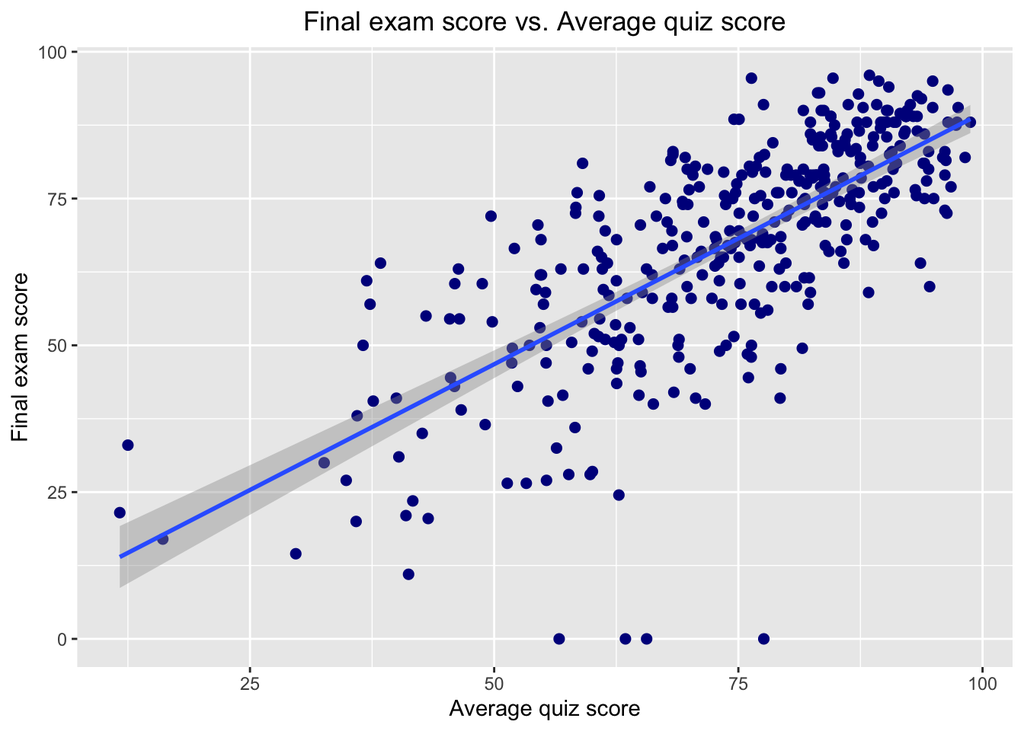

   ```r
   library(ggplot2)
   scatterplot = ggplot(statgrades, aes(quiz_average, final)) +
   geom_point(size=2, color='darkblue') +
   labs(title="Final exam score vs. Average quiz score",y="Final exam score",
   x="Average quiz score") + theme(legend.position = "none") + theme(plot.title = element_text(hjust = 0.5)) + geom_smooth(method=lm)
   plot(scatterplot)
   ```

   The regression line has a relatively good fit to the data. We see that there is a lot of variation of the points around the regression line. Our visual conclusion is also supported by the $R^2$ value with is about 52/7%.

   We also observe some unusual observations in the plot - which we will discuss later on how to handle!
4. Interpret $\hat{\beta}_0$ in your estimated regression function. Does $\hat{\beta}_0$ provide any relevant information here? Explain.

   In this case, $\hat{\beta}_0 = 3.95$, which implies that a student with zero average quiz score would get 3.95 on the final? Well, the intercept in this case does not have a meaningful interpretation. The value zero was not in the observed data, so this extrapolation is not necessarily correct.
5. Obtain a point estimate of the mean `Final Exam` score for a student with `Quiz Average` equal to 60.

   ```r
    predict(grades.lm, newdata=data.frame(quiz_average=60))
   ```

   ```
   ##        1
   ## 55.34714
   ```

6. Estimate the difference in the mean `Final Exam` score for two students whose `Quiz Average` differs by 1. Use a 90% confidence interval.

   ```r
   confint(grades.lm)
   ```

   ```
   ##                   2.5 %     97.5 %
   ## (Intercept)  -2.2560794 10.1504238
   ## quiz_average  0.7747862  0.9385462
   ```

7. Obtain a 90% confidence interval for the mean `Final Exam` score for students with `Quiz Average` equal to 85.

   ```r
   predict(grades.lm, newdata=data.frame(quiz_average=85),interval='confidence',level=0.9)
   ```

   ```
   ##       fit      lwr      upr
   ## 1 76.7638 75.44682 78.08077
   ```

8. Obtain a 90% prediction interval for the mean `Final Exam` score for a new student with `Quiz Average` equal to 85. Is your prediction interval wider than the corresponding confidence interval? Should it be?

```r
 predict(grades.lm, newdata=data.frame(quiz_average=85),interval='prediction',level=0.9)
```

```
##       fit      lwr      upr
## 1 76.7638 55.54486 97.98273
```

The 90% prediction interval is wider than the corresponding 90% confidence interval, which is expected.

9. Conduct an $F$ test to determine whether or not there is a linear association between `Final Exam` score and `Quiz Average`. Use $\alpha$ equal to 0.1. State the alternatives, decision rule and conclusion.

   The hypothesis we want to test is formulated as follows:
   $$\begin{cases}
   &H_0: \beta_1=0\\
   &H_{\alpha}: \beta_1\neq 0\\
   \end{cases}$$

   We can perform this test using the `anova` function in R:

   ```r
    anova(grades.lm)
   ```

   |  | Df | Sum Sq | Mean Sq | F value | Pr(>F) |
   | --- | --- | --- | --- | --- | --- |
   | quiz_average | 1 | 69812.09 | 69812.0896 | 423.189 | 9.84919e-64 |
   | Residuals | 380 | 62687.34 | 164.9667 | NA | NA |

   Using the p-value, we reject the null hypothesis and conclude that the slope coefficient is a statistically significant and that there is a linear association between `Final Exam score` and `Quiz Average`.
10. By how much relatively is the total variation in the `Final Exam` score reduced when the `Quiz Average` is introduced into the analysis? Is this a relatively small or large reduction? What is the name of this measure?

    This is measured by $R^2$

    ```r
    summary(grades.lm)$r.square
    ```

    ```
    ## [1] 0.5268859
    ```

    Here, it is approximately 52.7% which is a medium-sized reduction.
11. Calculate $r$ (the correlation coefficient) and attach the appropriate sign.

    ```r
    sqrt(summary(grades.lm)$r.square)
    ```

    ```
    ## [1] 0.7258691
    ```

    The correct sign for the correlation coeffcient is the `+` sign, since this os the sign of the slope coefficient.